# TD_5_ML_Flavien_Galbez_IBO4.R

flavi

2019-11-06

```r
############################################################
############################################################
######### TD5 Machine Learning : Flavien GALBEZ ############
############################################################
############################################################

#setwd("~/Cours ESILV/Annee 4/S7/Machine Learning")

library(MASS)
```

```r
library(corrplot)
library(caTools)
```

Importing the Data set :

```r
set.seed(706888)
dataset <- read.csv("C:/Users/flavi/OneDrive/Bureau/flow_dataset.csv")

dim(dataset)
```

```
## [1] 5000   15
```

```r
summary(dataset)
```

```
##      Origin                  Name_origin    Destination
##  Min.   :75101   Ville-d'Avray     :  98   Min.   :75101
##  1st Qu.:77523   Marnes-la-Coquette:  97   1st Qu.:77511
##  Median :92019   Meudon            :  87   Median :92019
##  Mean   :87324   Sceaux            :  84   Mean   :87304
##  3rd Qu.:92060   Bois-Colombes     :  83   3rd Qu.:92051
##  Max.   :95682   SÃ¨vres           :  82   Max.   :95682
##                  (Other)           :4469
##             Name_destination      Pros             Students
##  Bourg-la-Reine     : 106    Min.   :    0.00   Min.   :    0.00
##  Marnes-la-Coquette :  96    1st Qu.:    0.00   1st Qu.:    0.00
##  Fontenay-aux-Roses :  93    Median :    0.00   Median :    0.00
##  AsniÃ¨res-sur-Seine:  86    Mean   :   52.37   Mean   :   13.63
##  Le Plessis-Robinson:  83    3rd Qu.:    0.00   3rd Qu.:    0.00
##  Gennevilliers      :  81    Max.   :32809.70   Max.   :17581.00
##  (Other)            :4455
##  Pros_plus_Students     Pro_PT            Pro_2R            Pro_PC
##  Min.   :    0.00   Min.   :   0.00   Min.   :  0.000   Min.   :   0.00
##  1st Qu.:    0.00   1st Qu.:   0.00   1st Qu.:  0.000   1st Qu.:   0.00
##  Median :    0.00   Median :   0.00   Median :  0.000   Median :   0.00
##  Mean   :   52.37   Mean   :  20.83   Mean   :  2.664   Mean   :  11.77
##  3rd Qu.:    0.00   3rd Qu.:   0.00   3rd Qu.:  0.000   3rd Qu.:   0.00
##  Max.   :32809.70   Max.   :4083.30   Max.   :718.600   Max.   :2124.60
##
##     Pro_soft            Pop_Or          Pop_Dest         Distance
##  Min.   :   0.000   Min.   :    84   Min.   :    84   Min.   :  0.00
##  1st Qu.:   0.000   1st Qu.:  1161   1st Qu.:  1185   1st Qu.: 42.10
##  Median :   0.000   Median : 11419   Median : 17662   Median : 56.25
##  Mean   :   3.465   Mean   : 23946   Mean   : 24552   Mean   : 58.58
##  3rd Qu.:   0.000   3rd Qu.: 37089   3rd Qu.: 38817   3rd Qu.: 75.50
##  Max.   :8476.900   Max.   :235366   Max.   :235366   Max.   :134.50
##
##     Flow_OD
##  Min.   :    0.00
##  1st Qu.:    0.83
##  Median :    1.66
##  Mean   :  122.24
##  3rd Qu.:    6.64
##  Max.   :42498.49
##
```

```r
str(dataset)
```

```
## 'data.frame':    5000 obs. of  15 variables:
##  $ Origin            : int  95014 77466 77227 91080 78647 92035 92004 77421 92019 92032 ...
##  $ Name_origin       : Factor w/ 866 levels "Ãchouboulains",..: 26 777 340 96 817 381 41 704 147 273 ...
##  $ Destination       : int  92072 92047 92073 92072 92002 77268 77411 92072 78576 77406 ...
##  $ Name_destination  : Factor w/ 859 levels "Ãchouboulains",..: 660 477 762 660 30 462 690 660 713 680 ...
##  $ Pros              : num  0 0 0 0 0 0 0 0 0 0 ...
##  $ Students          : num  0 0 0 0 0 0 0 0 0 0 ...
##  $ Pros_plus_Students: num  0 0 0 0 0 0 0 0 0 0 ...
##  $ Pro_PT            : num  0 0 0 0 0 0 0 0 0 0 ...
##  $ Pro_2R            : num  0 0 0 0 0 0 0 0 0 0 ...
##  $ Pro_PC            : num  0 0 0 0 0 0 0 0 0 0 ...
##  $ Pro_soft          : num  0 0 0 0 0 0 0 0 0 0 ...
##  $ Pop_Or            : int  2539 378 650 1312 821 29072 86799 276 33067 22946 ...
##  $ Pop_Dest          : int  23206 1712 48526 23206 61603 8297 505 23206 1430 935 ...
##  $ Distance          : num  25.5 68 115 52.7 63.3 57.6 81.3 95 37 77.5 ...
##  $ Flow_OD           : num  3.32 1.66 3.32 0.83 8.3 ...
```

We can see the different data In us case, we want to describe the number of travel following diferent parameters We can already see that the relative data with the students and employees are unusable We will not use the name of cities and their number so we remove them:

```r
dataset$Origin <- NULL
dataset$Name_origin <- NULL
dataset$Destination <- NULL
dataset$Name_destination <- NULL
```

So as well many data are unusable and not interesting because they are null

```r
dataset$Pros <- NULL
dataset$Students <- NULL
dataset$Pro_PT <- NULL
dataset$Pro_2R <- NULL
dataset$Pros_plus_Students <- NULL
dataset$Pro_PC <- NULL
dataset$Pro_soft <- NULL

dim(dataset)
```

```
## [1] 5000    4
```

```r
summary(dataset)
```

```
##      Pop_Or          Pop_Dest         Distance         Flow_OD
##  Min.   :    84   Min.   :    84   Min.   :  0.00   Min.   :    0.00
##  1st Qu.:  1161   1st Qu.:  1185   1st Qu.: 42.10   1st Qu.:    0.83
##  Median : 11419   Median : 17662   Median : 56.25   Median :    1.66
##  Mean   : 23946   Mean   : 24552   Mean   : 58.58   Mean   :  122.24
##  3rd Qu.: 37089   3rd Qu.: 38817   3rd Qu.: 75.50   3rd Qu.:    6.64
##  Max.   :235366   Max.   :235366   Max.   :134.50   Max.   :42498.49
```

```r
str(dataset)
```

```
## 'data.frame':    5000 obs. of  4 variables:
##  $ Pop_Or  : int  2539 378 650 1312 821 29072 86799 276 33067 22946 ...
##  $ Pop_Dest: int  23206 1712 48526 23206 61603 8297 505 23206 1430 935 ...
##  $ Distance: num  25.5 68 115 52.7 63.3 57.6 81.3 95 37 77.5 ...
##  $ Flow_OD : num  3.32 1.66 3.32 0.83 8.3 ...
```

We explore and describe the data set

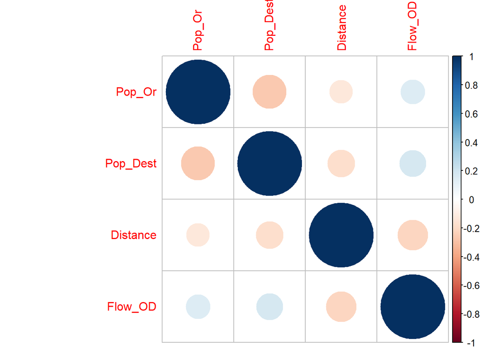

```r
M<-round(cor(dataset),2)
corrplot(M)
```

```r
set.seed(706888)
split = sample.split(dataset$Flow_OD, SplitRatio = 0.75)
```

We choose to split 75% of data

```r
training_set = subset(dataset, split == TRUE)
training_set [,1:4] = scale(training_set)[,1:4]
# we use subset to split the SNA_Data
test_set = subset(dataset, split == FALSE)
test_set [,1:4] = scale(test_set)[,1:4]

dim(training_set)
```

```
## [1] 3840    4
```

```r
summary(training_set)
```

```
##      Pop_Or           Pop_Dest          Distance           Flow_OD
##  Min.   :-0.8302   Min.   :-0.8177   Min.   :-2.19270   Min.   :-0.1252
##  1st Qu.:-0.7932   1st Qu.:-0.7818   1st Qu.:-0.62553   1st Qu.:-0.1245
##  Median :-0.3345   Median :-0.2555   Median :-0.07894   Median :-0.1239
##  Mean   : 0.0000   Mean   : 0.0000   Mean   : 0.00000   Mean   : 0.0000
##  3rd Qu.: 0.4821   3rd Qu.: 0.4211   3rd Qu.: 0.65496   3rd Qu.:-0.1192
##  Max.   : 7.1414   Max.   : 6.7070   Max.   : 2.94837   Max.   :33.7336
```

```r
str(training_set)
```

```
## 'data.frame':    3840 obs. of  4 variables:
##  $ Pop_Or  : num  -0.747 -0.811 -0.789 0.152 0.811 ...
##  $ Pop_Dest: num  -0.0782 0.7316 -0.0782 -0.555 -0.7847 ...
##  $ Distance: num  -1.218 2.20301 -0.17832 0.00898 0.02427 ...
##  $ Flow_OD : num  -0.123 -0.123 -0.125 -0.122 -0.118 ...
```

```r
dim(test_set)
```

```
## [1] 1160    4
```

```r
summary(test_set)
```

```
##      Pop_Or           Pop_Dest          Distance          Flow_OD
##  Min.   :-0.8026   Min.   :-0.8422   Min.   :-2.1737   Min.   :-0.4074
##  1st Qu.:-0.7643   1st Qu.:-0.7997   1st Qu.:-0.7411   1st Qu.:-0.3569
##  Median :-0.4828   Median :-0.4546   Median :-0.1520   Median :-0.3065
##  Mean   : 0.0000   Mean   : 0.0000   Mean   : 0.0000   Mean   : 0.0000
##  3rd Qu.: 0.3176   3rd Qu.: 0.3851   3rd Qu.: 0.6936   3rd Qu.:-0.1551
##  Max.   : 3.5108   Max.   : 3.8853   Max.   : 2.9463   Max.   : 9.4809
```

```r
str(test_set)
```

```
## 'data.frame':    1160 obs. of  4 variables:
##  $ Pop_Or  : num  -0.792 -0.775 2.399 -0.795 0.415 ...
##  $ Pop_Dest: num  -0.7769 1.6466 -0.8257 0.0929 -0.7883 ...
##  $ Distance: num  0.2295 0.0303 0.7932 1.3739 -1.0844 ...
##  $ Flow_OD : num  -0.3065 0.0971 -0.2056 0.9043 -0.3065 ...
```

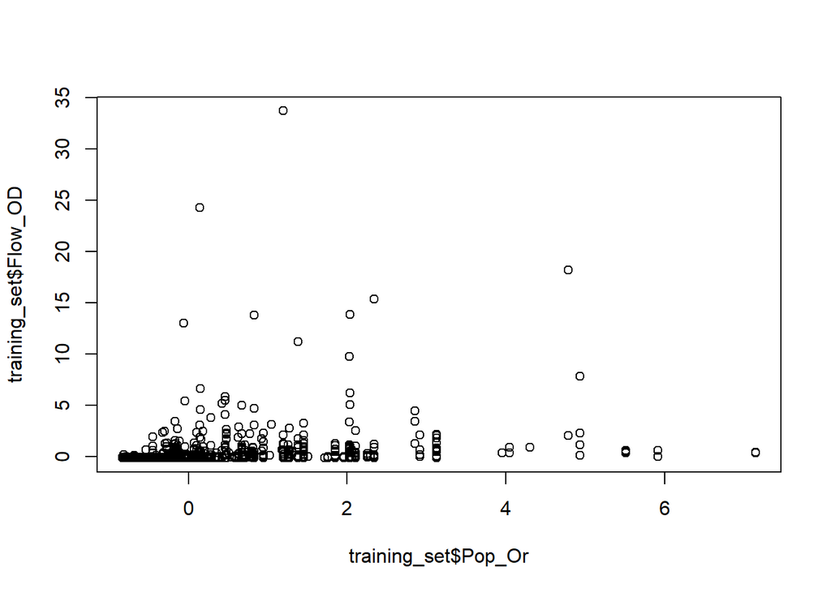

```r
plot(training_set$Pop_Or, training_set$Flow_OD)
```

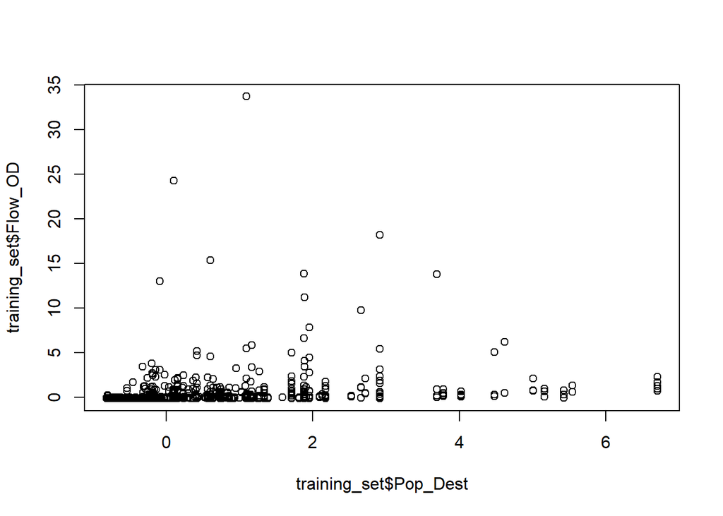

```r
plot(training_set$Pop_Dest, training_set$Flow_OD)
```